# 🧪 Introduction to SFcalculator_torch: the basics

This notebook demonstrates how to use [`SFcalculator_torch`](https://github.com/Hekstra-Lab/SFcalculator_torch) — a PyTorch-based toolkit for computing structure factors from atomic models in macromolecular crystallography and cryo electron microscopy.

You'll learn how to:

- Load a PDB structure and MTZ reflection data
- Compute structure factors for the protein and solvent
- Combine them into a total model structure factor
- Evaluate model quality via R-factors
- Optionally optimize scaling factors to improve fit

## 🛠️ 1. Installation and Imports

If you haven't installed SFCalculator yet, you can do it following:

1. Install [PyTorch](https://pytorch.org/get-started/locally/)
2. `pip install sfcalculator-torch`

The imports necessary for this notebook:

```python
import torch
import numpy as np
import matplotlib.pyplot as plt
import SFC_Torch as sfc
import reciprocalspaceship as rs
from reciprocalspaceship.algorithms import scale_merged_intensities
```

## 📂 2. Loading Experimental Data and the Atomic Model

SFCalculator's core capabilities are the calculation of structure factors from a model, and the comparison to observations in the form of R factors. For likelihood-based calculations, please see [ROCKET Codebase](https://github.com/alisiafadini/ROCKET/blob/main/rocket/xtal/targets.py).

Let`s first fetch a dataset from the PDB, SFCalculator provides a utility function to fetch entries from the PDB database by entry ID. It also supports batch fetching.

```python
df = sfc.fetch_pdb(idlist=["7lvc"], outpath="./")
```

It will attempt to download the sequence FASTA file, molecular model CIF file, structure factor CIF file, PDB file, and structure factor MTZ file when available. A CSV file indicates which file formats were fetched for each entry ID.

```python
!ls
```

```
7lvc.cif	    7lvc.pdb	  refined_model.pdb
7lvc.fasta	    7lvc-sf.cif   SFcalculator_torch_demo_with_patterson.html
7lvc_FW_scaled.mtz  fetchpdb.csv  SFcalculator_torch_demo_with_patterson.ipynb
```

The we use [reciprocal spaceship](https://rs-station.github.io/reciprocalspaceship/) to inspect our dataset.

```python
ds=rs.read_cif("7lvc-sf.cif")
ds.head()
```

| H | K | L | FreeR_flag | I(+) | SIGI(+) | I(-) | SIGI(-) | FWT | PHWT | DELFWT | PHDELWT |
| --- | --- | --- | --- | --- | --- | --- | --- | --- | --- | --- | --- |
| 16 | 11 | 3 | 12 | 78.059998 | 7.19 | 79.589996 | 5.27 | 110.150002 | 124.489998 | 46.810001 | -55.5 |
|  |  | 2 | 9 | 170.080002 | 11.66 | 163.039993 | 8.03 | 175.240005 | 90.769997 | 41.369999 | -89.389999 |
|  |  | 1 | 12 | 98.040001 | 5.8 | 91.389999 | 5.36 | 142.119995 | -103.32 | 8.52 | 76.629997 |
|  | 10 | 7 | 8 | 111.849998 | 8.45 | 98.43 | 5.57 | 157.660004 | 156.199997 | 5.93 | 155.820007 |
|  |  | 6 | 0 | 9.92 | 2.98 | 7.66 | 2.28 | 16.26 | -164.720001 | 38.34 | 13.24 |

We see that we have separate Friedel mates recorded for the intensities. There are also amplitude columns, but these are 2Fo-Fc amplitudes (FWT), Fo-Fc (FWT) and phases, not raw observations! (see [Global Phasing's Kwiki](https://www.globalphasing.com/buster/wiki/index.cgi?MTZcolumns) for more details). As a consequence, we should first "stack" the Friedel mates, and then French-Wilson scale them. For example like this:

```python
ds=ds.stack_anomalous()
ds_scaled = scale_merged_intensities(
        ds,
        intensity_key="I",
        sigma_key="SIGI",
        output_columns=["FW-I", "FW-SIGI", "F", "SIGF"],
        inplace=False,
        mean_intensity_method="anisotropic",
        bw=2.0,
        minimum_sigma=1e-6,
    )
ds_scaled.write_mtz("7lvc_FW_scaled.mtz")

ds_scaled.head()
```

| H | K | L | FreeR_flag | I | SIGI | FWT | PHWT | DELFWT | PHDELWT | dHKL | CENTRIC | FW-I | FW-SIGI | F | SIGF |
| --- | --- | --- | --- | --- | --- | --- | --- | --- | --- | --- | --- | --- | --- | --- | --- |
| 16 | 11 | 3 | 12 | 78.059998 | 7.19 | 110.150002 | 124.489998 | 46.810001 | -55.5 | 1.900489 | False | 77.590569 | 7.19 | 8.799018 | 0.409693 |
|  |  | 2 | 9 | 170.080002 | 11.66 | 175.240005 | 90.769997 | 41.369999 | -89.389999 | 1.902241 | False | 168.864914 | 11.66 | 12.987023 | 0.449588 |
|  |  | 1 | 12 | 98.040001 | 5.8 | 142.119995 | -103.32 | 8.52 | 76.629997 | 1.903295 | False | 97.741295 | 5.8 | 9.882053 | 0.293788 |
|  | 10 | 7 | 8 | 111.849998 | 8.45 | 157.660004 | 156.199997 | 5.93 | 155.820007 | 1.921573 | False | 111.219727 | 8.45 | 10.538425 | 0.401649 |
|  |  | 6 | 0 | 9.92 | 2.98 | 16.26 | -164.720001 | 38.34 | 13.24 | 1.926292 | False | 9.845529 | 2.971575 | 3.098016 | 0.497819 |

Now, let's read in these data, together with a model, into an `SFCalculator` object: the core object that keeps track of our calculations.

```python
pdb_path = "7lvc.cif"
mtz_path = "7lvc_FW_scaled.mtz"

sf = sfc.SFcalculator(pdb_path, mtz_path, device=torch.device("cuda" if torch.cuda.is_available() else "cpu"),
                      anomalous=True, mode="xray",
                      expcolumns=["F","SIGF"],
                      freeflag="FreeR_flag", testset_value=0, wavelength=1.892)

print("Model loaded with", sf.n_atoms, "atoms in space group", sf.space_group.hm)
print("Number of reflections in dataset: ", len(sf.HKL_array))
```

```
2025-07-16 11:56:57.851 | WARNING  | SFC_Torch.Fmodel:init_pdb:147 - Can't find wavelength record in the PDB file, or it doesn't match your input wavelength!
2025-07-16 11:56:57.988 | WARNING  | SFC_Torch.Fmodel:init_mtz:357 - Can't find wavelength record in the MTZ file, or it doesn't match with other sources
```

```
Model loaded with 2985 atoms in space group P 21 21 21
Number of reflections in dataset:  27967
```

## 🧮 3. Computing Structure Factors

For an accurate and efficient calcualtion, we first need to inspect it for an appropriate solvent percentage and a reasonable grid size for FFT:

```python
sf.inspect_data(verbose=True)
```

```
Solvent Percentage: tensor(0.2636, device='cuda:0')
Grid size: [64, 90, 180]
```

Next, we calculate the contributions from the protein and from solvent to the overall structure factor. If we want their actual complex values as a seperate variable, we can add `Return=True`. Internally, the are stored as `sfcalculator.Fprotein_HKL` and `sfcalculator.Fmask_HKL`.

```python
F_protein = sf.calc_fprotein(Return=True)
F_solvent = sf.calc_fsolvent()
```

```python
print(F_protein)
```

```
tensor([-77.0283+111.0421j,  -9.1909+192.4632j, -31.6068-130.6637j,
         ..., -29.2952+10.9436j,   2.5986+11.8835j,
        -14.9516-75.6051j], device='cuda:0')
```

We also need to calculate some global scale paramters (stored internally as `sfcalculator.kmasks`, `sfcalculator.uanisos`, `sfcalculator.kisos`). To get an initial, analytical estimate, we can run `sf.init_scales`. A more optimized value can be obtained using `sf.get_scales_adam()`.

```python
%%time
sf.init_scales(requires_grad=True)
```

```
CPU times: user 76.9 ms, sys: 16 ms, total: 92.9 ms
Wall time: 91.6 ms
```

The total structure factor has been calculated already at this point. We can retrieve it using

```python
Fmodel = sf.calc_ftotal()
```

And it is differentiably calculated with respect to the gradient_required parameters, which can be scale factors or the **atomic model coordinates**.

```python
Fmodel
```

```
tensor([-6.3304+9.1257j, -0.7553+15.8170j, -2.5975-10.7382j,  ...,
        -2.4075+0.8994j,  0.2136+0.9766j, -1.2287-6.2131j], device='cuda:0',
       grad_fn=<IndexPutBackward0>)
```

## 📏 4. Evaluating Model Quality with R-factors

We can get a sense of overall fit of the model to the data using R factors:

```python
print(f"R-factors (work, free): {100 * sf.get_rfactors()[0]:.4}% and {100 * sf.get_rfactors()[1]:.4}%")
```

```
R-factors (work, free): 15.34% and 18.88%
```

We can use the Adam optimizer to estimate more accurate scales and see that this helps:

```python
%%time
sf.get_scales_adam(n_steps=100, initialize=False)
```

```
CPU times: user 9.2 s, sys: 511 ms, total: 9.71 s
Wall time: 10.8 s
```

```python
print(f"R-factors (work, free): {100 * sf.get_rfactors()[0]:.4}% and {100 * sf.get_rfactors()[1]:.4}%")
```

```
R-factors (work, free): 14.71% and 18.19%
```

or use an LBFGS optimizer,

```python
%%time
sf.get_scales_lbfgs(initialize=True)
print(f"R-factors (work, free): {100 * sf.get_rfactors()[0]:.4}% and {100 * sf.get_rfactors()[1]:.4}%")
```

```
R-factors (work, free): 14.79% and 18.29%
CPU times: user 4.3 s, sys: 7.81 ms, total: 4.31 s
Wall time: 4.34 s
```

and can obtain more granular information using `SFCalculator.summarize()`

```python
sf.summarize()
```

```
Resolution       N_work  N_free  <Fobs> <|Fmodel|>  R_work  R_free  k_mask   k_iso
49.52 - 11.37        93       7    21.8      19.4   0.344   0.221   0.068   0.052
11.37 - 9.12        107       2    24.0      21.9   0.237   0.764   0.065   0.061
9.12 - 7.39         173      11    23.2      21.8   0.245   0.226   0.058   0.075
7.39 - 5.99         334      17    19.7      18.1   0.226   0.305   0.050   0.075
5.99 - 4.86         634      22    24.2      23.0   0.199   0.196   0.022   0.073
4.86 - 3.94        1157      72    29.2      28.2   0.156   0.178   0.019   0.070
3.94 - 3.20        2169     142    24.4      23.9   0.147   0.170   0.012   0.083
3.20 - 2.59        4068     227    16.5      16.1   0.146   0.189   0.003   0.085
2.59 - 2.10        7596     388    11.9      11.7   0.135   0.179   0.000   0.083
2.10 - 1.70       10260     488     7.8       7.6   0.132   0.178   0.000   0.085
r_work: 0.148
r_free: 0.183
Number of outliers: 0
```

## 💾 6. Exporting a Refined PDB Model

```python
sf.savePDB("refined_model.pdb")
```

## 🧬 7. Bonus: Computing and Visualizing a Patterson Map

A **Patterson map** is the Fourier transform of |F_obs|² (squared structure factor amplitudes). It reveals interatomic vector densities and is especially useful when phase information is unavailable, e.g. as a target during Molecular Replacement.

We'll compute a Patterson map and visualize a central slice through the origin.

We first generate an array of patterson vectors and calculate the patterson map intensity on those points

```python
%%time
patterson_uvw_arr_frac = sfc.patterson.uvw_array_frac(sf.unit_cell, 1.0, 20.0, 0.3)
Pu_o = sfc.patterson.Patterson_torch(patterson_uvw_arr_frac,
                                     sf.Fo, sf.HKL_array, sf.unit_cell.volume,
                                     sharpen=True, remove_origin=True,
                                     PARTITION=10000)
```

```
CPU times: user 233 ms, sys: 17.3 ms, total: 251 ms
Wall time: 52.6 ms
```

Then we fill in the grid with the above two arrays, using simple rounding operations for now

```python
patterson_grid = np.zeros(sf.gridsize)
grid_size_arr = np.array(sf.gridsize)
scaled_coords = sfc.utils.assert_numpy(patterson_uvw_arr_frac) * grid_size_arr
integer_indices = np.round(scaled_coords, decimals=0).astype(int)
integer_indices = np.clip(integer_indices, 0, grid_size_arr - 1)
patterson_grid[tuple(integer_indices.T)] = sfc.utils.assert_numpy(Pu_o)
```

```python
patterson_grid.shape
```

```
(64, 90, 180)
```

```python
actual_grid_size = [sf.unit_cell.a, sf.unit_cell.b, sf.unit_cell.c]
print("Grid size in Angstroms:", actual_grid_size)
```

```
Grid size in Angstroms: [34.297, 45.552, 99.035]
```

Then we do a visualization of a slice

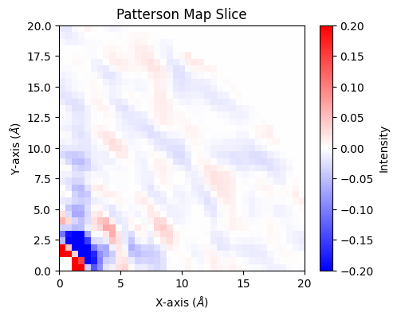

```python
show_range_x = int(20.0 / actual_grid_size[0] * sf.gridsize[0])
show_range_y = int(20.0 / actual_grid_size[1] * sf.gridsize[1])
slice_to_show = patterson_grid[:show_range_x, :show_range_y, 0]
fig, ax = plt.subplots(figsize=(5, 4))
im = ax.imshow(
    slice_to_show,
    extent=[0, 20.0, 0, 20.0],
    origin='lower',
    aspect='equal',
    cmap='bwr',
    vmin=-0.2, vmax=0.2
)

ax.set_xlabel(rf"X-axis ($\AA$)")
ax.set_ylabel(f"Y-axis ($\AA$)")
ax.set_title("Patterson Map Slice")
fig.colorbar(im, ax=ax, label="Intensity")

plt.show()
```

## 🧠 Summary and Next Steps

In this notebook, you've learned to:

✅ Load and parse a crystallographic model and reflection data  
✅ Compute structure factors using atomic scattering  
✅ Evaluate model quality with R and R-free  
✅ Optimize scale parameters with PyTorch  
✅ Save and analyze your results